# ThinkRobots

Jake Daniels

6/8/2020

# Data Cleaning

## Importing data

```r
library(tidyverse)
library(readxl)
library(lubridate)
```

```r
#load the data
read_from_excel <- function(file, sheet_number) {
  df <- read_xlsx(file, sheet = sheet_number) %>%
    janitor::clean_names()
  return(df)
}

customer_segments <- read_from_excel("ThinkRobots_2019.xlsx", sheet_number = 1)
customer_names <- read_from_excel("ThinkRobots_2019.xlsx", sheet_number = 2)
billing_status <- read_from_excel("ThinkRobots_2019.xlsx", sheet_number = 3)
major_product_changes <- read_from_excel("ThinkRobots_2019.xlsx", sheet_number = 4)
```

## Primary key check

### Customer Id

```r
#all customer ids are unique
n_distinct(customer_segments$customer_id)
```

```
## [1] 1000
```

```r
n_distinct(customer_names$customer_id)
```

```
## [1] 1000
```

```r
#ids do equal their counterpart
sum(customer_segments$customer_id == customer_names$customer_id)
```

```
## [1] 1000
```

These two tables can be cleanly merged.

```r
#merge customer data
customer_data <- customer_segments %>%
  left_join(customer_names, by = "customer_id")
```

### Billing Account Number

```r
n_distinct(billing_status$billing_account_number)
```

```
## [1] 993
```

```r
n_distinct(customer_data$billing_account_number)
```

```
## [1] 993
```

Seven entries have the same id

```r
#accounts with more than one entry
billing_status %>%
  count(billing_account_number) %>%
  filter(n > 1)
```

```
## # A tibble: 7 x 2
##   billing_account_number     n
##   <chr>                  <int>
## 1 AX#13658                   2
## 2 AX#26417                   2
## 3 AX#33896                   2
## 4 AX#45042                   2
## 5 AX#56582                   2
## 6 AX#84649                   2
## 7 AX#98628                   2
```

```r
#store duplicate account ids for querying
duplicate_accounts <- billing_status %>%
  count(billing_account_number) %>%
  filter(n > 1) %>%
  .$billing_account_number
```

The following table shows the duplicate entries. They hold unique information we’ll want to keep.

```r
billing_status %>%
  filter(billing_account_number %in% c(duplicate_accounts))
```

```
## # A tibble: 14 x 5
##    billing_account~ account_status upgraded_account_c~ upgraded_account_c~
##    <chr>            <chr>          <dttm>              <dttm>
##  1 AX#13658         paying         2018-11-11 00:00:00 NA
##  2 AX#13658         paying         2019-02-21 00:00:00 NA
##  3 AX#26417         paying         2018-11-08 00:00:00 NA
##  4 AX#26417         paying         2017-12-15 00:00:00 NA
##  5 AX#33896         cancelled      2018-04-14 00:00:00 2019-02-02 00:00:00
##  6 AX#33896         paying         2018-03-23 00:00:00 NA
##  7 AX#45042         paying         2019-04-01 00:00:00 NA
##  8 AX#45042         paying         2019-04-02 00:00:00 NA
##  9 AX#56582         paying         2018-07-31 00:00:00 NA
## 10 AX#56582         paying         2018-08-15 00:00:00 NA
## 11 AX#84649         paying         2019-03-03 00:00:00 NA
## 12 AX#84649         paying         2019-01-26 00:00:00 NA
## 13 AX#98628         paying         2019-03-26 00:00:00 NA
## 14 AX#98628         paying         2019-02-24 00:00:00 NA
## # ... with 1 more variable: total_charges <dbl>
```

## Fixing Duplicates

### Billing

```r
#add a -1 beside account number if there are two dates
duplicate_billing_fix <- billing_status %>%
  filter(billing_account_number %in% c(duplicate_accounts)) %>%
  group_by(billing_account_number) %>%
  mutate(billing_account_n = ifelse(
    upgraded_account_created_date == min(upgraded_account_created_date),
    paste0(billing_account_number, "-1"),
    billing_account_number)) %>%
  ungroup() %>%
  select(-billing_account_number) %>%
  rename(billing_account_number =  billing_account_n)

duplicate_billing_fix
```

```
## # A tibble: 14 x 5
##    account_status upgraded_account_c~ upgraded_account_c~ total_charges
##    <chr>          <dttm>              <dttm>                      <dbl>
##  1 paying         2018-11-11 00:00:00 NA                          750.
##  2 paying         2019-02-21 00:00:00 NA                          242.
##  3 paying         2018-11-08 00:00:00 NA                         1516.
##  4 paying         2017-12-15 00:00:00 NA                         2844.
##  5 cancelled      2018-04-14 00:00:00 2019-02-02 00:00:00        2195.
##  6 paying         2018-03-23 00:00:00 NA                          735.
##  7 paying         2019-04-01 00:00:00 NA                          129.
##  8 paying         2019-04-02 00:00:00 NA                           68.5
##  9 paying         2018-07-31 00:00:00 NA                          714.
## 10 paying         2018-08-15 00:00:00 NA                          555.
## 11 paying         2019-03-03 00:00:00 NA                          558.
## 12 paying         2019-01-26 00:00:00 NA                          503.
## 13 paying         2019-03-26 00:00:00 NA                          148.
## 14 paying         2019-02-24 00:00:00 NA                          462
## # ... with 1 more variable: billing_account_number <chr>
```

I added a `-1` to users with two dates. However, my approach is flawed, because it assumes users do not upgrade on the same date. If this date was instead full timestamp (down to minute and seconds), I would have more confidence that it would not throw an error. Again, I assume users cannot upgrade at the same time.

Also, there’s no way to be certain which user `first_name` belongs to which account, I’m just acknowledging there are two.

```r
#drop the multiple entries and bind single entry data back
billing_cleaned <- billing_status %>%
  filter(!billing_account_number %in% c(duplicate_accounts)) %>%
  bind_rows(duplicate_billing_fix)
```

### Customer

```r
#multiple users can have same billing_account number
duplicate_customer_fix <- customer_data %>%
  filter(billing_account_number %in% duplicate_accounts) %>%
  group_by(billing_account_number) %>%
  mutate(billing_account_n = ifelse(free_account_created_date == min(free_account_created_date), paste0(billing_account_number, "-1"), billing_account_number)) %>%
  ungroup() %>%
  select(-billing_account_number) %>%
  rename(billing_account_number =  billing_account_n)

duplicate_customer_fix
```

```
## # A tibble: 14 x 7
##    customer_id free_account_creat~ last_seen           session_count segment
##          <dbl> <dttm>              <dttm>                      <dbl> <chr>
##  1          13 2017-06-20 00:00:00 2019-04-23 15:55:56          2191 Market~
##  2          54 2017-12-17 00:00:00 2019-04-27 22:25:05           267 Market~
##  3         125 2018-04-08 00:00:00 2018-07-13 15:10:58             2 Market~
##  4         136 2018-04-21 00:00:00 2019-04-28 11:35:17            45 Market~
##  5         150 2018-05-22 00:00:00 2019-04-27 10:34:33           115 Market~
##  6         229 2018-08-12 00:00:00 2019-04-28 14:26:25           170 Market~
##  7         294 2018-09-18 00:00:00 2018-11-27 19:47:13             3 Market~
##  8         344 2018-10-16 00:00:00 2018-10-23 18:19:38             1 Market~
##  9         552 2019-01-04 00:00:00 2019-04-28 20:31:15           110 Market~
## 10         645 2019-02-05 00:00:00 2019-04-15 17:14:42             5 Market~
## 11         679 2019-02-17 00:00:00 2019-03-23 09:53:22            10 Market~
## 12         691 2019-02-21 00:00:00 2019-04-28 19:21:07            10 Market~
## 13         712 2019-02-25 00:00:00 2019-04-28 08:24:16            10 Market~
## 14         880 2019-04-02 00:00:00 2019-04-28 08:28:23             5 Market~
## # ... with 2 more variables: first_name <chr>, billing_account_number <chr>
```

```r
#drop the multiple entries and bind single entry data back
customer_cleaned <- customer_data %>%
  filter(!billing_account_number %in% c(duplicate_accounts)) %>%
  bind_rows(duplicate_customer_fix)
```

```r
#joining for full data
full_df <- billing_cleaned %>%
  left_join(customer_cleaned, by = "billing_account_number")

#looking at final entries that handled the duplicates
full_df %>%
  tail(10)
```

```
## # A tibble: 10 x 11
##    billing_account~ account_status upgraded_account_c~ upgraded_account_c~
##    <chr>            <chr>          <dttm>              <dttm>
##  1 AX#33896         cancelled      2018-04-14 00:00:00 2019-02-02 00:00:00
##  2 AX#33896-1       paying         2018-03-23 00:00:00 NA
##  3 AX#45042-1       paying         2019-04-01 00:00:00 NA
##  4 AX#45042         paying         2019-04-02 00:00:00 NA
##  5 AX#56582-1       paying         2018-07-31 00:00:00 NA
##  6 AX#56582         paying         2018-08-15 00:00:00 NA
##  7 AX#84649         paying         2019-03-03 00:00:00 NA
##  8 AX#84649-1       paying         2019-01-26 00:00:00 NA
##  9 AX#98628         paying         2019-03-26 00:00:00 NA
## 10 AX#98628-1       paying         2019-02-24 00:00:00 NA
## # ... with 7 more variables: total_charges <dbl>, customer_id <dbl>,
## #   free_account_created_date <dttm>, last_seen <dttm>, session_count <dbl>,
## #   segment <chr>, first_name <chr>
```

## NAs

```r
#creating real NAs
full_df <- full_df %>%
  mutate(upgraded_account_cancelled_date = str_replace(upgraded_account_cancelled_date, "<NA>", NA_character_))
```

## Hours since last session

```r
max(full_df$last_seen)
```

```
## [1] "2019-04-28 20:56:17 UTC"
```

I assume it is the next day at 9AM UTC when I am analyzing this.

```r
#hours since last session
full_df <- full_df %>%
  mutate(hours_since_last_seen = difftime(as.Date("2019-04-29 09:00:00"), last_seen)) %>%
  mutate(hours_since_last_seen = as.numeric(hours_since_last_seen))
```

## Days to upgrade free to paid

```r
full_df <- full_df %>%
  mutate(days_to_upgrade = as.numeric(difftime(upgraded_account_created_date, free_account_created_date, units = "days")))
```

## Churn

```r
#check if both indicators are correct
full_df %>%
  mutate(has_cancel_date = ifelse(!is.na(upgraded_account_cancelled_date), "yes", "no")) %>%
  count(account_status, has_cancel_date)
```

```
## # A tibble: 4 x 3
##   account_status has_cancel_date     n
##   <chr>          <chr>           <int>
## 1 cancelled      no                  2
## 2 cancelled      yes               120
## 3 paying         no                876
## 4 paying         yes                 2
```

There are instances where cancelled accounts do not have an `upgraded_account_cancelled_date` and paying accounts have an `upgraded_account_cancelled_date`, both instances are shown below:

```r
full_df %>%
  mutate(has_cancel_date = ifelse(!is.na(upgraded_account_cancelled_date), "yes", "no")) %>%
  filter(account_status == "cancelled" & has_cancel_date == "no")
```

```
## # A tibble: 2 x 14
##   billing_account~ account_status upgraded_account_c~ upgraded_accoun~
##   <chr>            <chr>          <dttm>              <chr>
## 1 AX#12986         cancelled      2019-04-21 00:00:00 <NA>
## 2 AX#21943         cancelled      2019-04-15 00:00:00 <NA>
## # ... with 10 more variables: total_charges <dbl>, customer_id <dbl>,
## #   free_account_created_date <dttm>, last_seen <dttm>, session_count <dbl>,
## #   segment <chr>, first_name <chr>, hours_since_last_seen <dbl>,
## #   days_to_upgrade <dbl>, has_cancel_date <chr>
```

These users have been inactive for no longer than 136 hours. They are likely active. But for this project, I will hold `account_status` as truth.

```r
full_df %>%
  mutate(has_cancel_date = ifelse(!is.na(upgraded_account_cancelled_date), "yes", "no")) %>%
  filter(account_status == "paying" & has_cancel_date == "yes")
```

```
## # A tibble: 2 x 14
##   billing_account~ account_status upgraded_account_c~ upgraded_accoun~
##   <chr>            <chr>          <dttm>              <chr>
## 1 AX#27911         paying         2018-05-12 00:00:00 2018-06-09
## 2 AX#27988         paying         2018-12-02 00:00:00 2019-03-26
## # ... with 10 more variables: total_charges <dbl>, customer_id <dbl>,
## #   free_account_created_date <dttm>, last_seen <dttm>, session_count <dbl>,
## #   segment <chr>, first_name <chr>, hours_since_last_seen <dbl>,
## #   days_to_upgrade <dbl>, has_cancel_date <chr>
```

These users have `last_seen` dates more recent than their `upgraded_account_cancelled_date` - they are still active, but may have reverted to a free account. Again, I will hold `account_status` as truth as these edge cases require more investigation.

```r
#customer is churned if account status as cancelled
full_df <- full_df %>%
  mutate(churned = ifelse(account_status == "cancelled", TRUE, FALSE))
```

# Product Insights Prep

## Churn

```r
#churn
marketing_segment_churn_raw <- full_df %>%
  group_by(segment) %>%
  summarize(total_churned = sum(churned),
            n_signups = n(),
            churn_rate = total_churned / n_signups)

DT::datatable(marketing_segment_churn_raw)
```

|  | segment | total_churned | n_signups | churn_rate |
| --- | --- | --- | --- | --- |
| 1 | Marketing Segment 1 | 17 | 254 | 0.0669291338582677 |
| 2 | Marketing Segment 2 | 57 | 402 | 0.141791044776119 |
| 3 | Marketing Segment 3 | 48 | 344 | 0.13953488372093 |

## Campaign Length

```r
#length
marketing_segment_length <- full_df %>%
  group_by(segment) %>%
  summarize(marketing_start = min(upgraded_account_created_date),
            marketing_end = max(upgraded_account_created_date)) %>%
  mutate(length = difftime(marketing_end, marketing_start))

DT::datatable(marketing_segment_length)
```

|  | segment | marketing_start | marketing_end | length |
| --- | --- | --- | --- | --- |
| 1 | Marketing Segment 1 | 2017-12-03T00:00:00Z | 2019-04-28T00:00:00Z | 511 |
| 2 | Marketing Segment 2 | 2017-12-04T00:00:00Z | 2019-04-28T00:00:00Z | 510 |
| 3 | Marketing Segment 3 | 2017-12-11T00:00:00Z | 2019-04-27T00:00:00Z | 502 |

## Activity

```r
#activity
marketing_segment_activity <- full_df %>%
  group_by(segment) %>%
  mutate(heavy_users = ifelse(session_count > as.numeric(quantile(full_df$session_count, 0.75)), 1, 0)) %>%
  summarize(n_signups = n(),
            total_sessions = sum(session_count),
            median_sessions = median(session_count),
            avg_sessions_per_user = total_sessions / n_signups,
            heavy_users = sum(heavy_users))

DT::datatable(marketing_segment_activity)
```

|  | segment | n_signups | total_sessions | median_sessions | avg_sessions_per_user | heavy_users |
| --- | --- | --- | --- | --- | --- | --- |
| 1 | Marketing Segment 1 | 254 | 93141 | 13 | 366.696850393701 | 84 |
| 2 | Marketing Segment 2 | 402 | 177972 | 16 | 442.716417910448 | 116 |
| 3 | Marketing Segment 3 | 344 | 39862 | 6.5 | 115.877906976744 | 49 |

## Revenue

```r
#revenue
marketing_revenue_activity <- full_df %>%
  group_by(segment) %>%
  summarize(n_signups = n(),
            total_revenue = sum(total_charges),
            median_revenue = median(total_charges),
            avg_revenue_per_user = total_revenue / n_signups)

DT::datatable(marketing_revenue_activity)
```

|  | segment | n_signups | total_revenue | median_revenue | avg_revenue_per_user |
| --- | --- | --- | --- | --- | --- |
| 1 | Marketing Segment 1 | 254 | 167929.4 | 274.2 | 661.13937007874 |
| 2 | Marketing Segment 2 | 402 | 225187.1 | 313.133333333333 | 560.166915422886 |
| 3 | Marketing Segment 3 | 344 | 164161.966666667 | 256.966666666667 | 477.215019379845 |

## Conversion

```r
#average days to upgrade from free
marketing_avg_days <- full_df %>%
  group_by(segment) %>%
  summarize(median_days_to_upgrade = median(days_to_upgrade),
            avg_days_to_upgrade = mean(days_to_upgrade))

DT::datatable(marketing_avg_days)
```

|  | segment | median_days_to_upgrade | avg_days_to_upgrade |
| --- | --- | --- | --- |
| 1 | Marketing Segment 1 | 23 | 81.3346456692913 |
| 2 | Marketing Segment 2 | 10.5 | 34.0547263681592 |
| 3 | Marketing Segment 3 | 13 | 34.9970930232558 |

# Full Segment Insights

```r
#full data
marketing_df <- marketing_segment_churn_raw %>%
  left_join(marketing_segment_length) %>%
  left_join(marketing_segment_activity) %>%
  left_join(marketing_revenue_activity) %>%
  left_join(marketing_avg_days)

DT::datatable(marketing_df)
```

|  | segment | total_churned | n_signups | churn_rate | marketing_start | marketing_end | length | total_sessions | median_sessions | avg_sessions_per_user | heavy_users | total_revenue | median_revenue | avg_revenue_per_user | median_days_to_upgrade | avg_days_to_upgrade |
| --- | --- | --- | --- | --- | --- | --- | --- | --- | --- | --- | --- | --- | --- | --- | --- | --- |
| 1 | Marketing Segment 1 | 17 | 254 | 0.0669291338582677 | 2017-12-03T00:00:00Z | 2019-04-28T00:00:00Z | 511 | 93141 | 13 | 366.696850393701 | 84 | 167929.4 | 274.2 | 661.13937007874 | 23 | 81.3346456692913 |
| 2 | Marketing Segment 2 | 57 | 402 | 0.141791044776119 | 2017-12-04T00:00:00Z | 2019-04-28T00:00:00Z | 510 | 177972 | 16 | 442.716417910448 | 116 | 225187.1 | 313.133333333333 | 560.166915422886 | 10.5 | 34.0547263681592 |
| 3 | Marketing Segment 3 | 48 | 344 | 0.13953488372093 | 2017-12-11T00:00:00Z | 2019-04-27T00:00:00Z | 502 | 39862 | 6.5 | 115.877906976744 | 49 | 164161.966666667 | 256.966666666667 | 477.215019379845 | 13 | 34.9970930232558 |

# Meeting Questions

## Which of the existing marketing segments is the most effective?

Conclusion and future actions are at the bottom of each tab.

### S1 - “Loyal Users”

**Segment 1 has a statistically significantly lower churn rate than the other segment campaigns.**

This was measured using a `prop.test` where `n_signups` was the sample size, and `total_churned` was the testing variable.

I used a one-sided test to determine if the churn rate is lower in Segment 1 than 2 or 3.

```r
#proof
prop.test(c(marketing_segment_churn_raw[1,]$total_churned, marketing_segment_churn_raw[2,]$total_churned),
          c(marketing_segment_churn_raw[1,]$n_signups, marketing_segment_churn_raw[2,]$n_signups),
          alternative = "less")
```

```
##
##  2-sample test for equality of proportions with continuity correction
##
## data:  c(marketing_segment_churn_raw[1, ]$total_churned, marketing_segment_churn_raw[2,  out of c(marketing_segment_churn_raw[1, ]$n_signups, marketing_segment_churn_raw[2,     ]$total_churned) out of     ]$n_signups)
## X-squared = 7.9843, df = 1, p-value = 0.002359
## alternative hypothesis: less
## 95 percent confidence interval:
##  -1.00000000 -0.03312467
## sample estimates:
##     prop 1     prop 2
## 0.06692913 0.14179104
```

```r
prop.test(c(marketing_segment_churn_raw[1,]$total_churned, marketing_segment_churn_raw[3,]$total_churned),
          c(marketing_segment_churn_raw[1,]$n_signups, marketing_segment_churn_raw[3,]$n_signups),
          alternative = "less")
```

```
##
##  2-sample test for equality of proportions with continuity correction
##
## data:  c(marketing_segment_churn_raw[1, ]$total_churned, marketing_segment_churn_raw[3,  out of c(marketing_segment_churn_raw[1, ]$n_signups, marketing_segment_churn_raw[3,     ]$total_churned) out of     ]$n_signups)
## X-squared = 7.2187, df = 1, p-value = 0.003607
## alternative hypothesis: less
## 95 percent confidence interval:
##  -1.00000000 -0.02906516
## sample estimates:
##     prop 1     prop 2
## 0.06692913 0.13953488
```

We can see p-value < 0.05 in the tests above.

**Segment 1 has a the highest average revenue per user.**

However, this is because of a cluster of users in upper ranges. We should investigate what these users have in common. And when examining the median, we see it is not the most efficient segment at generating revenue. But it still earns us a lot of money.

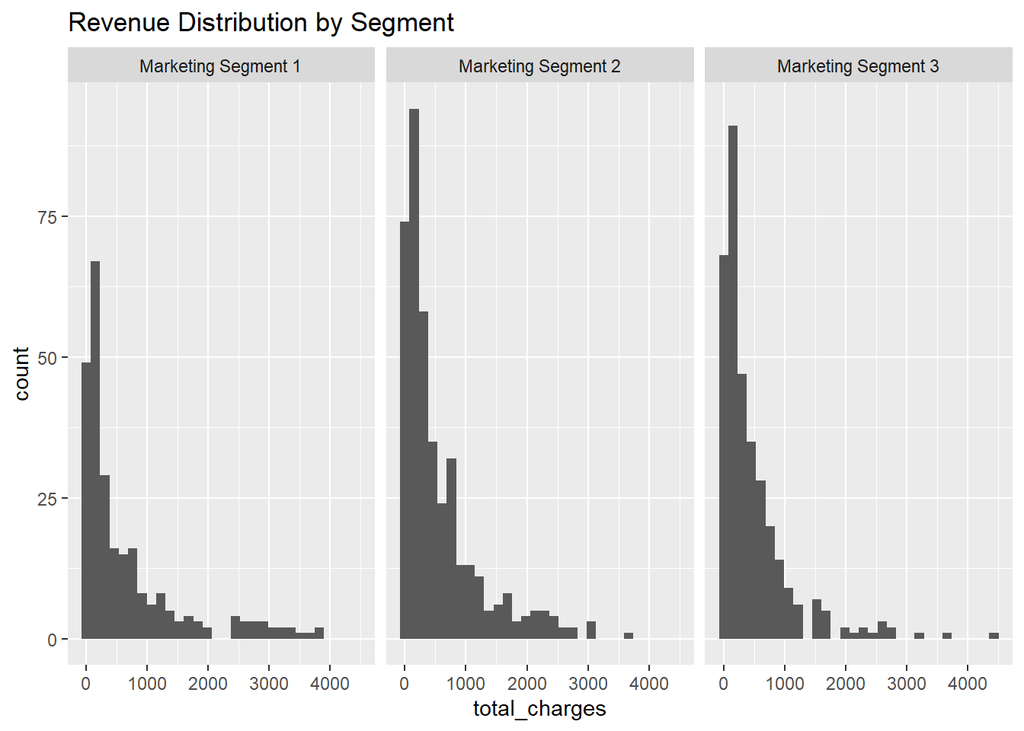

```r
full_df %>%
  ggplot(aes(x = total_charges)) +
  geom_histogram() +
  labs(title = "Revenue Distribution by Segment") +
  facet_wrap(~segment)
```

**Segment 1 has fewer signups than other segments.**

However, this is compensated by the user’s loyalty. They stay around with us. A low conversion rate, but a better retention rate would be worth allocating more adversting dollars into.

**Segment 1 take much longer than the other segments to convert from free to upgraded accounts**

It takes about 2.5x as long to convert our loyal users into upgraded accounts than the other segments.

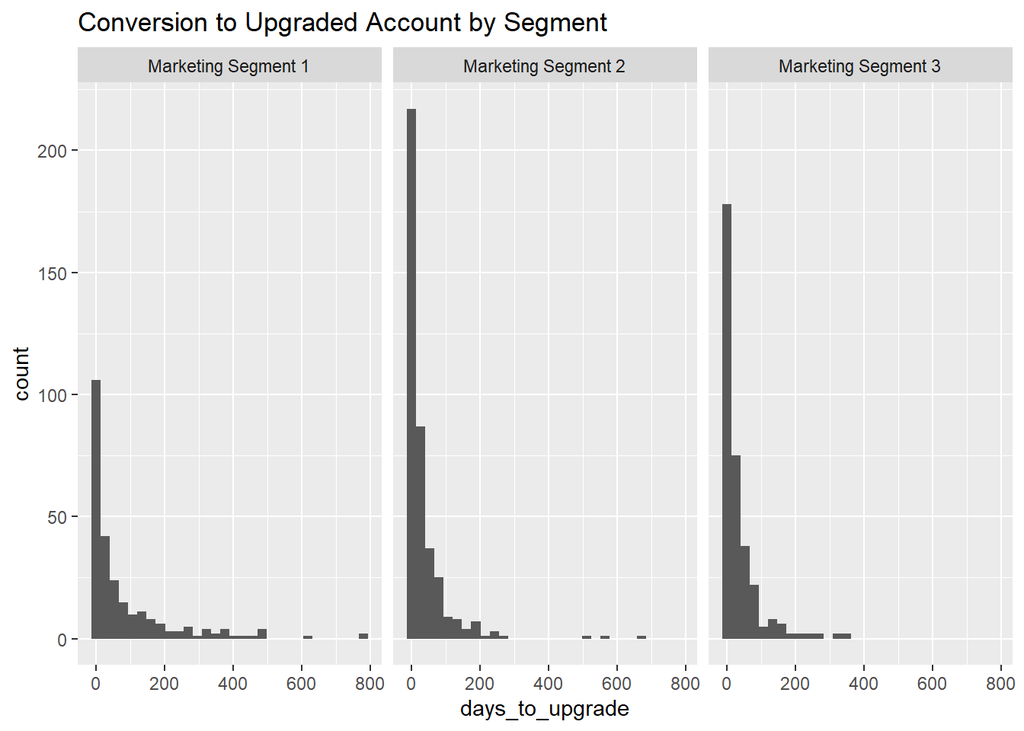

```r
full_df %>%
  ggplot(aes(x = days_to_upgrade)) +
  geom_histogram() +
  labs(title = "Conversion to Upgraded Account by Segment") +
  facet_wrap(~segment)
```

In conclusion, these users used the free product longer and then upgraded. This would reasonably lead to the higher retention rate, they are loyal. I would recommend pushing these users to upgraded accounts, but when our churn rate is so low that it will be tricky to not disrupt it. In any case, we should spend more money on this segment as it will have the highest customer lifetime value.

Scroll back up for Segment 2/3.

### S2 - “Engaged Users”

**Segment 2 has the most volatile campaign — it brought in the most signups, but also holds the highest churn.**

Seeing as this campaign’s churn rate matches segment 3, we can possibly recognize segment 1 had a different target audience. A 12-14% churn rate could be acceptable. We should continue advertising to these users since they drive revenue, and just figure out a better way to retain them.

**Segment 2 has the most active users.**

Hence the title, it has the most average sessions per user within it. It also has the highest median sessions and boasts nearly 50% of `heavy_users` (those with `total_sessions` in the 75%+ range). I still declare it most active despite the outlier.

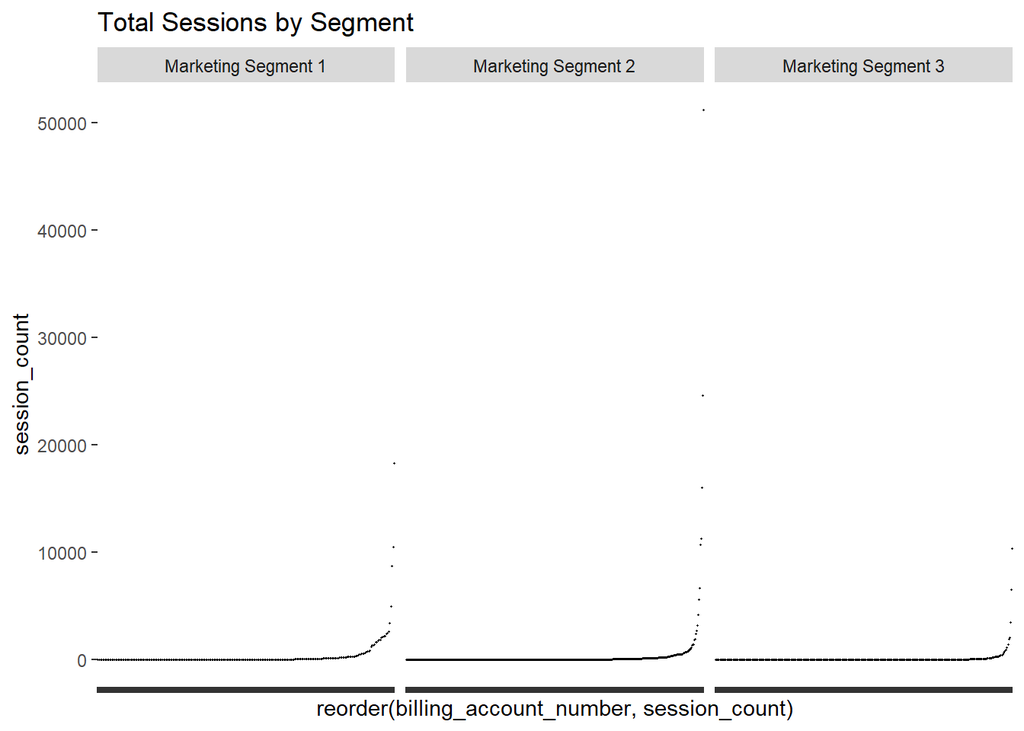

```r
full_df %>%
  ggplot(aes(x = reorder(billing_account_number, session_count), y = session_count)) +
  geom_point(size = 0.2) +
  labs(title = "Total Sessions by Segment") +
  facet_wrap(~segment, scales = "free_x") +
  coord_cartesian(clip = "off") +
  theme(axis.text.x = element_blank())
```

**Segment 2 has great revenue and conversion into free to upgraded accounts**

When using the Median statistics — this segment excels at driving people to premium accounts.

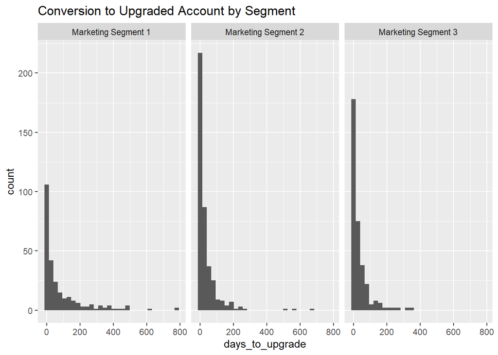

```r
full_df %>%
  ggplot(aes(x = days_to_upgrade)) +
  geom_histogram() +
  labs(title = "Conversion to Upgraded Account by Segment") +
  facet_wrap(~segment)
```

In conclusion, this segment brings lots of active users into the app. Retention tactics should be the focus of this cohort.

Scroll back up for Segment 1/3.

### S3 - “Casual Users”

**Segment 3 has VERY low activity across sessions.**

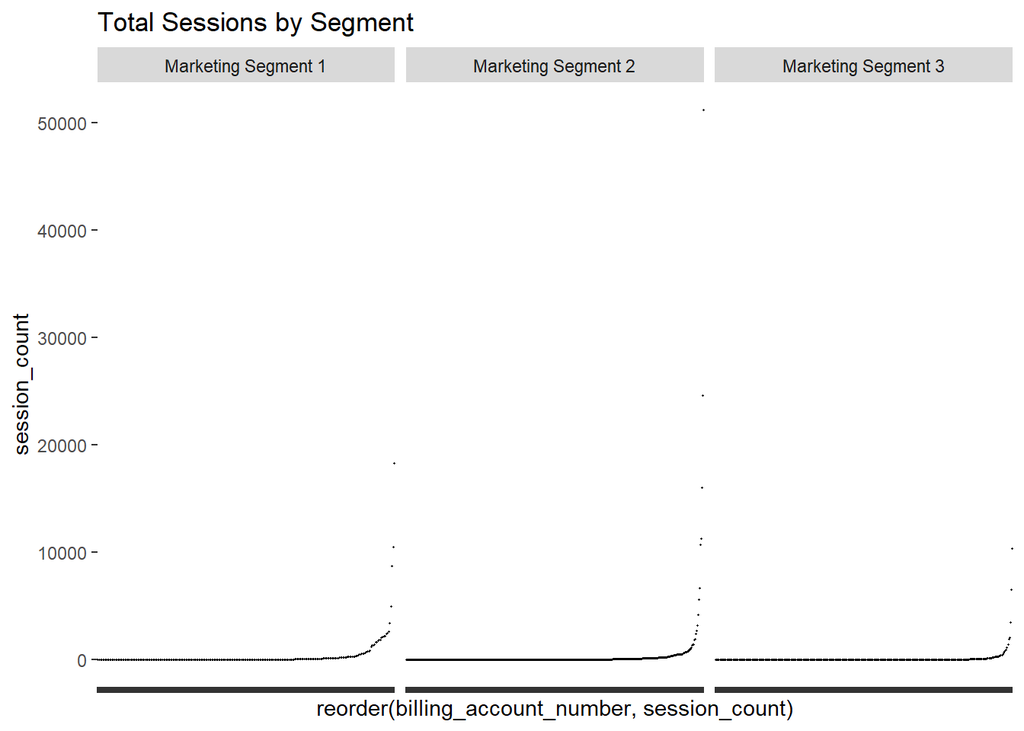

```r
full_df %>%
  ggplot(aes(x = reorder(billing_account_number, session_count), y = session_count)) +
  geom_point(size = 0.2) +
  labs(title = "Total Sessions by Segment") +
  facet_wrap(~segment, scales = "free_x") +
  coord_cartesian(clip = "off") +
  theme(axis.text.x = element_blank())
```

**But it matches revenue to segment 1 and converts to upgraded accounts faster.**

It seems these are casual users since other metrics outside activity remain similar to segment 2.

In conclusion, incentivizing the the users to be more active should be the goal of this segment.

## The team is considering running a test campaign on Facebook ads. How should they decide if it’s a success?

The goal of a Facebook campaign is to drive signups - the churn rate and activity should not be considered.

One can A/B test: the number of signups driven by the campaign, to the number of impressions. The more impressions we have, the more confident we can be in determining if one segment is statistically different than the other.

If we are re-running ads, we can compare our new results to a previous. This may indicate confounding economic reasons behind the success of a campaign (ex. COVID-19 = more premium).

And if we made minor difference, we could check if it improved the conversion rate.

Finally, adjust our Facebook ads to serve ads to demographics that were performing best and tailor messaging/ads for them.

**A/B Example:**

Here’s a small A/B test simulation using sign ups from segment 2 and 3:

```r
segment_2 <- marketing_segment_churn_raw %>%
  filter(segment == "Marketing Segment 2")

segment_3 <- marketing_segment_churn_raw %>%
  filter(segment == "Marketing Segment 3")
```

If both have 10,000 impressions…

```r
prop.test(c(segment_2$n_signups, segment_3$n_signups),
          c(10000, 10000),
          alternative = "greater")
```

```
##
##  2-sample test for equality of proportions with continuity correction
##
## data:  c(segment_2$n_signups, segment_3$n_signups) out of c(10000, 10000)
## X-squared = 4.524, df = 1, p-value = 0.01671
## alternative hypothesis: greater
## 95 percent confidence interval:
##  0.00129251 1.00000000
## sample estimates:
## prop 1 prop 2
## 0.0402 0.0344
```

… we can confirm segment 2’s sign ups are statistically greater than segment 3’s. Thus, we reject the null hypothesis that 2 is equal to 3 using a one-sided test.

## Any other advice?

More data on the customer can allow us to understand their behaviour; socioeconomic factors like age and gender are obvious, but perhaps an oboarding questionnaire with qualitative results would allow us to ask “why did you sign up for this app?”, “how many people are at your company?”, and other questions so we can better understand *why* people are coming to us, and how to successfully tailor our messaging to them.

Also, if each segment is attracting different people (perhaps through messaging), each segment should have different KPIs.

I suggest spending more money on segment 1 since converting them faster can cause more issues for us.

Potential KPI: `Days to convert to premium`.

I suggest focusing on retaining the users in segment 2 since they leave at the highest rate, but spend lots of money with us.

Potential KPI: `Retention`.

I suggest incetivizing actibity for users in segment 3 since they have low session counts.

Potential KPI: `Activity`.

But, perhaps accepting these campaigns draw different kinds people is fine. Loyal, Engaged, and Casual users may like using the app like they do and pushing other habits may not work. Splitting these segments AGAIN into test & control groups would allow us to test new messaging with less risk before pushing it onto more users.

Thanks for reading,

~jakeD